# Entregable Reproducibilidad-control versiones

Mario

2026-02-19

En este trabajo se ha recogido un extracto del total de la base de datos completa perteneciente al Trabajo Fin de Grado de Mario Martínez Hernández en la Universidad de Sevilla, año 2025.

Para el análisis se han utilizado los datos del muestreo realizado a finales de 2024 para 4 individuos de *Retama monosperma* de 25 años de edad. Se muestreó cada 0,5m hasta 2m del límite de la copa al exterior.

[figure not shown]

Flor de *Retama monosperma*.Florandalucía.es(J.Fuentes)

```r
datos_TFG<- read.csv("C:/Users/mario/Desktop/Repositorio_Git_Mario/Extracto_TFG_Mario.csv")

df<- read_delim("C:/Users/mario/Desktop/Repositorio_Git_Mario/Extracto_TFG_Mario.csv", delim = ";")

datos_listos <- df %>%
  mutate(across(c(distancia, fruto_Viejo, fruto_nuevo, fruto,
                  individuales, total),
                ~as.numeric(str_replace_all(as.character(.), ",", "."))))

datos_densidad <- datos_listos %>%
  mutate(densidad_m2 = total / 0.07)


resumen_muestras <- datos_densidad %>%
  group_by(ID_muestra) %>%
  summarise(
    Densidad_Media = mean(densidad_m2),
    SD = sd(densidad_m2),
    Total_Semillas = sum(total)
  )

print(head(resumen_muestras))
```

```
## # A tibble: 6 × 4
##   ID_muestra Densidad_Media    SD Total_Semillas
##   <chr>               <dbl> <dbl>          <dbl>
## 1 CL25_1_1            1286.    NA             90
## 2 CL25_1_10            171.    NA             12
## 3 CL25_1_11              0     NA              0
## 4 CL25_1_12              0     NA              0
## 5 CL25_1_13              0     NA              0
## 6 CL25_1_14              0     NA              0
```

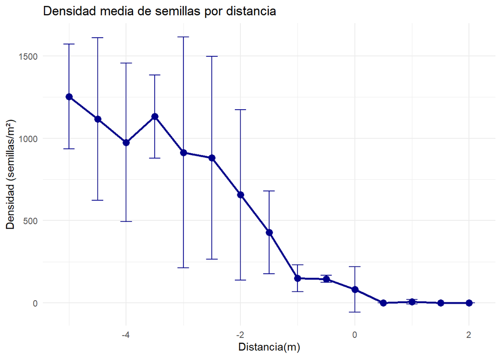

```r
datos_grafico <- datos_densidad %>%
  group_by(distancia) %>%
  summarise(
    Media_Densidad = mean(densidad_m2),
    SD_Densidad = sd(densidad_m2),
    n = n()
  ) %>%
  mutate(SE = SD_Densidad / sqrt(n))

ggplot(datos_grafico, aes(x = distancia, y = Media_Densidad)) +
  geom_line(color = "darkblue", size = 1) +
  geom_point(color = "darkblue", size = 3) +

  geom_errorbar(aes(ymin = Media_Densidad - SD_Densidad,
                    ymax = Media_Densidad + SD_Densidad),
                width = 0.2, color = "darkblue") +
  theme_minimal() +
  labs(title = "Densidad media de semillas por distancia",
       x = "Distancia(m)",
       y = "Densidad (semillas/m²)")
```

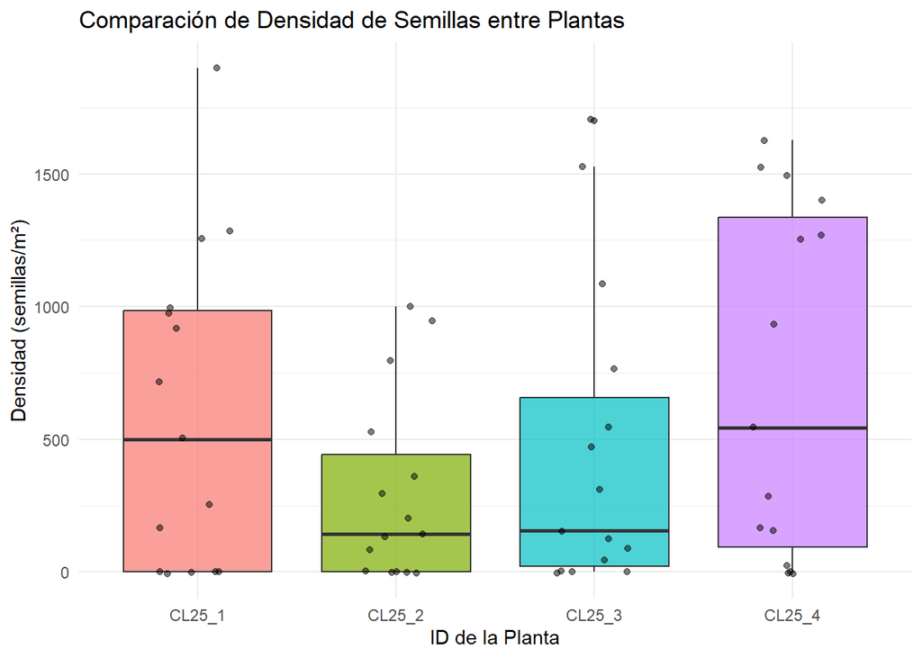

```r
datos_con_planta <- datos_listos %>%
  mutate(Planta = str_extract(ID_muestra, "CL25_\\d+"))


datos_con_planta <- datos_con_planta %>%
  mutate(densidad_m2 = total / 0.07) # Cambia 0.01 por tu área real

ggplot(datos_con_planta, aes(x = Planta, y = densidad_m2, fill = Planta)) +
  geom_boxplot(alpha = 0.7) +

  geom_jitter(width = 0.2, alpha = 0.5) +
  theme_minimal() +
  labs(title = "Comparación de Densidad de Semillas entre Plantas",
       x = "ID de la Planta",
       y = "Densidad (semillas/m²)") +
  theme(legend.position = "none") # Quitar leyenda si el eje X ya es claro
```

La alta densidad del banco de semillas de la especie de estudion debe tenerse en cuenta al planificar y ejecutar protocolos de control de la misma, especialmente si se trata de eliminar la parte aérea de la planta, ya que tal densidad del banco de semillas supone un alto potencial de regeneración

Mario Martínez Hernández

Ecoinformática. 17/02/2026